# R Notebook

```r
#load necessary libraries
library(dplyr)
library(readxl)
library(ggplot2)
library(ggpubr)
library(qqplotr)
#library(car)
library(e1071)
library(nortest)
library(BSDA)
options("scipen"=100, "digits"=6)
```

# 10.23

## Beer and blood alcohol

### A) Solution:

```r
file_name = "ex10-23bac.xls"
df = read_xls(file_name)
df
```

| Beers | BAC |
| --- | --- |
| 5 | 0.100 |
| 2 | 0.030 |
| 9 | 0.190 |
| 8 | 0.120 |
| 3 | 0.040 |
| 7 | 0.095 |
| 3 | 0.070 |
| 5 | 0.060 |
| 3 | 0.020 |
| 5 | 0.050 |

[output cut: 6 more lines]

```r
summary(df)
```

```
     Beers           BAC
 Min.   :1.00   Min.   :0.0100
 1st Qu.:3.00   1st Qu.:0.0475
 Median :5.00   Median :0.0700
 Mean   :4.81   Mean   :0.0737
 3rd Qu.:6.25   3rd Qu.:0.0963
 Max.   :9.00   Max.   :0.1900
```

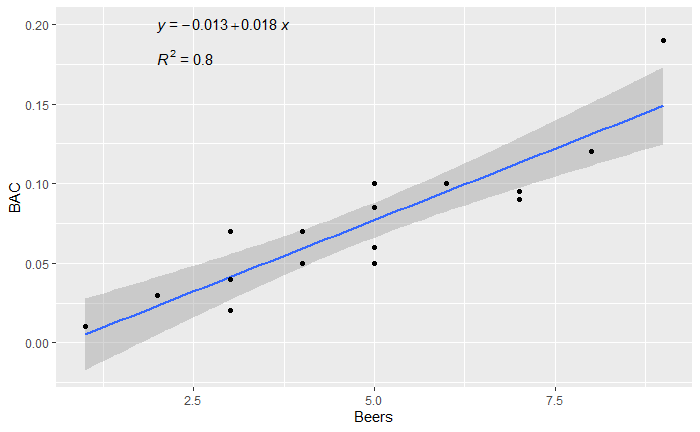

```r
ggplot(data=df, aes(x=Beers, y=BAC)) +
        geom_smooth(method="lm") +
        geom_point() +
        stat_regline_equation(label.x=2, label.y=.20) +
        stat_cor(aes(label=..rr.label..), label.x=2, label.y=.18)
```

```r
fit<- lm(df$BAC~ df$Beers)
summary(fit)
```

```
Call:
lm(formula = df$BAC ~ df$Beers)

Residuals:
     Min       1Q   Median       3Q      Max
-0.02712 -0.01735  0.00177  0.00862  0.04103

Coefficients:
            Estimate Std. Error t value Pr(>|t|)
(Intercept)  -0.0127     0.0126   -1.00     0.33
df$Beers      0.0180     0.0024    7.48 0.000003 ***
---
Signif. codes:  0 ‘***’ 0.001 ‘**’ 0.01 ‘*’ 0.05 ‘.’ 0.1 ‘ ’ 1

Residual standard error: 0.0204 on 14 degrees of freedom
Multiple R-squared:   0.8,  Adjusted R-squared:  0.786
F-statistic: 55.9 on 1 and 14 DF,  p-value: 0.00000297
```

```r
# Least squared regression equation
b = unname(fit$coefficients[1])
a = unname(fit$coefficients[2])
paste0("Least squared regression equation is: y = ",round(a,5),"x + ",round(b,5))
```

```
[1] "Least squared regression equation is: y = 0.01796x + -0.0127"
```

```r
# r^2 value
summary(fit)$r.squared
```

```
[1] 0.799841
```

*So r-squared value is 79.98%.*

### B) Solution:

*The null hypothesis:* H0: B = 0 *The alternate hypothesis:* H1: B > 0

```r
summary(fit)$coefficients
```

```
              Estimate Std. Error  t value      Pr(>|t|)
(Intercept) -0.0127006  0.0126375 -1.00499 0.33195513245
df$Beers     0.0179638  0.0024017  7.47959 0.00000296948
```

*From the obtained output above, the test statistic value corresponding to the beers is t = 7.48 and the two tailed P-value is 0.00000296948.* *Obviously one-tailed P-value is less than this (closer to zero). The P-value is less than any level of significance. So we can reject the null hypothesis.* *Therefore, it can be concluded that drinking more beers increases BAC.*

### C) Solution:

```r
# So
x = 5
# The estimated mean balance is
y = a*x + b
y
```

```
[1] 0.0771182
```

```r
# The standard error for beer is
se = summary(fit)$coefficients[2,2]
```

```r
# 90% prediction interval
predict.lm(fit, data.frame(x), interval = "predict", level = 0.9)[1,]
```

```
      fit       lwr       upr
0.0771182 0.0399988 0.1142376
```

*90% prediction interval for Steve’s BAC is (0.040, 0.114). The upper limit in the prediction interval is way past the legal limit. So he cannot be too confident.*

# 10.28

## Sales price versus assessed value, continued

```r
file_name = "ex10-28sales.xls"
df = read_xls(file_name)
df = filter(df, Property != 11)
df
```

| Property | Sales Price | Assessed Value |
| --- | --- | --- |
| 1 | 179.9 | 188.7 |
| 2 | 240.0 | 220.4 |
| 3 | 113.5 | 118.1 |
| 4 | 281.5 | 232.4 |
| 5 | 186.0 | 188.1 |
| 6 | 275.0 | 240.1 |
| 7 | 281.5 | 232.4 |
| 8 | 210.0 | 211.8 |
| 9 | 210.0 | 168.0 |
| 10 | 184.0 | 180.3 |

[output cut: 19 more lines]

```r
summary(df)
```

```
    Property     Sales Price  Assessed Value
 Min.   : 1.0   Min.   :114   Min.   :118
 1st Qu.: 8.0   1st Qu.:172   1st Qu.:169
 Median :16.0   Median :189   Median :192
 Mean   :15.7   Mean   :202   Mean   :194
 3rd Qu.:23.0   3rd Qu.:239   3rd Qu.:220
 Max.   :30.0   Max.   :282   Max.   :307
```

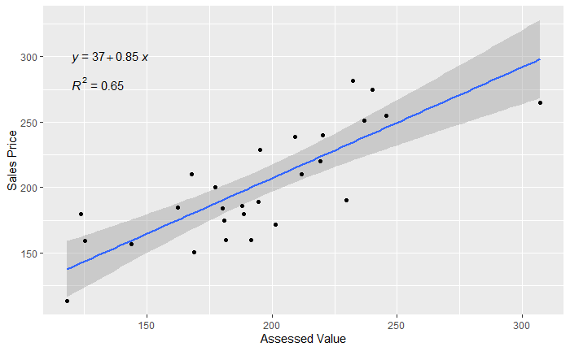

```r
ggplot(data=df, aes(x=`Assessed Value`, y= `Sales Price`)) +
        geom_smooth(method="lm") +
        geom_point() +
        stat_regline_equation(label.x=120, label.y=300) +
        stat_cor(aes(label=..rr.label..), label.x=120, label.y=280)
```

```r
cor(df$`Assessed Value`,df$`Sales Price`, method = "pearson")
```

```
[1] 0.804064
```

```r
fit<- lm(df$`Sales Price`~ df$`Assessed Value`)
summary(fit)
```

```
Call:
lm(formula = df$`Sales Price` ~ df$`Assessed Value`)

Residuals:
   Min     1Q Median     3Q    Max
-42.39 -17.69  -2.56  15.50  46.81

Coefficients:
                    Estimate Std. Error t value   Pr(>|t|)
(Intercept)           37.410     23.927    1.56       0.13
df$`Assessed Value`    0.849      0.121    7.03 0.00000015 ***
---
Signif. codes:  0 ‘***’ 0.001 ‘**’ 0.01 ‘*’ 0.05 ‘.’ 0.1 ‘ ’ 1

Residual standard error: 26.8 on 27 degrees of freedom
Multiple R-squared:  0.647, Adjusted R-squared:  0.633
F-statistic: 49.4 on 1 and 27 DF,  p-value: 0.000000149
```

```r
# Least squared regression equation
b = unname(fit$coefficients[1])
a = unname(fit$coefficients[2])
paste0("Least squared regression equation is: y = ",round(a,5),"x + ",round(b,5))
```

```
[1] "Least squared regression equation is: y = 0.84886x + 37.41025"
```

### A) Solution:

```r
new_x = c(155,220,285)
new_data = data.frame('assessed_value_in_thousand' = new_x)
new_data$predicted_value_in_thousand = a*new_data$assessed_value + b
new_data
```

| assessed_value_in_thousand | predicted_value_in_thousand |
| --- | --- |
| 155 | 168.9839 |
| 220 | 224.1600 |
| 285 | 279.3360 |

### B) Solution:

```r
# 95% prediction interval of the slope
confint(fit, level=.95)
```

```
                         2.5 %   97.5 %
(Intercept)         -11.684215 86.50471
df$`Assessed Value`   0.601012  1.09671
```

*So 95% prediction interval of the slope is (0.601012, 1.09671). With every increase in thousand dollars assessed value of a home, sales price increases between $601.01 and $1096.71.*

### C) Solution:

*The intercept shows the value of y at x = 0 and there would be no sales price/ property for which assessed value is $0. Therefore, inference of b (intercept) is not interest for this problem.*

### D) Solution:

*The 95% confidence interval of the slope contains 1. This suggest that it is plausible that average value is equal to sales value (y = x).*

# 10.45

## Completing an ANOVA table

```r
# Here
dft = 19
# So sample size
n = dft+1
n
```

```
[1] 20
```

```r
# Number of independent variables
k = 1
dfm = 1
# So, degrees of freedom for the residual error
dfe = n - 2
dfe
```

```
[1] 18
```

```r
# from the minitab output
sst = 8251.5
ssm = 4947.2
sse = sst - ssm
sse
```

```
[1] 3304.3
```

```r
# model mean sum of squares
msm = ssm/dfm
msm
```

```
[1] 4947.2
```

```r
# error mean sum of square
mse = sse/dfe
mse
```

```
[1] 183.572
```

```r
# calculated F ratio
f = msm/mse
f
```

```
[1] 26.9496
```

```r
# The complete ANOVA table
a_tbl = data.frame("Source" = c("Regression", "Residual Error", "Total"), "DF" = c(dfm, dfe,dft), "SS"= c(ssm, sse,sst), "MS"= c(msm,mse,NA), "F" = c(f,NA,NA))
a_tbl
```

| Source | DF | SS | MS | F |
| --- | --- | --- | --- | --- |
| Regression | 1 | 4947.2 | 4947.2000 | 26.94961 |
| Residual Error | 18 | 3304.3 | 183.5722 | NA |
| Total | 19 | 8251.5 | NA | NA |

# 11.37

## Predicting bone formation

### A) Solution:

```r
file_name = "ex11-37biomark.xls"
df = read_xls(file_name)
df
```

| voplus | vominus | oc | loc | trap | ltrap | lvoplus | lvominus |
| --- | --- | --- | --- | --- | --- | --- | --- |
| 1606 | 903 | 68.9 | 4.232656 | 19.4 | 2.965 | 7.382 | 6.806 |
| 2240 | 1761 | 56.3 | 4.030695 | 25.5 | 3.239 | 7.714 | 7.474 |
| 2221 | 1486 | 54.6 | 4.000034 | 19.0 | 2.944 | 7.706 | 7.304 |
| 896 | 1116 | 31.2 | 3.440418 | 9.0 | 2.197 | 6.798 | 7.018 |
| 2545 | 2236 | 36.4 | 3.594569 | 19.1 | 2.950 | 7.842 | 7.712 |
| 878 | 954 | 31.4 | 3.446808 | 14.6 | 2.681 | 6.778 | 6.861 |
| 1682 | 1251 | 52.8 | 3.966511 | 25.2 | 3.227 | 7.428 | 7.132 |
| 1100 | 918 | 38.4 | 3.648057 | 14.6 | 2.681 | 7.003 | 6.822 |
| 1557 | 1446 | 35.7 | 3.575151 | 28.8 | 3.360 | 7.351 | 7.277 |
| 1251 | 1065 | 76.5 | 4.337291 | 14.9 | 2.701 | 7.132 | 6.971 |

[output cut: 21 more lines]

```r
fit = lm(voplus ~ oc, data = df)
summary(fit)
```

```
Call:
lm(formula = voplus ~ oc, data = df)

Residuals:
   Min     1Q Median     3Q    Max
-727.5 -234.4  -85.1   43.7 1501.0

Coefficients:
            Estimate Std. Error t value Pr(>|t|)
(Intercept)   334.03     159.24    2.10    0.045 *
oc             19.50       4.13    4.73 0.000054 ***
---
Signif. codes:  0 ‘***’ 0.001 ‘**’ 0.01 ‘*’ 0.05 ‘.’ 0.1 ‘ ’ 1

Residual standard error: 443 on 29 degrees of freedom
Multiple R-squared:  0.435, Adjusted R-squared:  0.416
F-statistic: 22.3 on 1 and 29 DF,  p-value: 0.0000543
```

```r
anova(fit)
```

```
Analysis of Variance Table

Response: voplus
          Df  Sum Sq Mean Sq F value    Pr(>F)
oc         1 4388785 4388785   22.34 0.0000543 ***
Residuals 29 5698276  196492
---
Signif. codes:  0 ‘***’ 0.001 ‘**’ 0.01 ‘*’ 0.05 ‘.’ 0.1 ‘ ’ 1
```

```r
# Least squared regression equation
b = unname(fit$coefficients[1])
a = unname(fit$coefficients[2])
paste0("Least squared regression equation is: Voplus = ",round(a,5),"Oc + ",round(b,5))
```

```
[1] "Least squared regression equation is: Voplus = 19.50471Oc + 334.03439"
```

```r
# R-squared value
summary(fit)$r.squared
```

```
[1] 0.435091
```

*So the R-squared value is 43.51% .* *The t statistics is 4.73 .* *The p-value is 0.0000543 .*

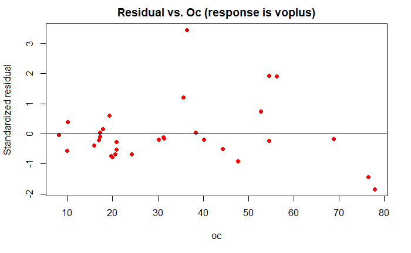

```r
res = resid(fit)
st_res = rstandard(fit)
plot(df$oc, st_res, pch=19, col = 'red', main = "Residual vs. Oc (response is voplus)", xlab = "oc", ylab = "Standardized residual")
abline(0,0, lwd=1)
```

*From the above plot we observe that the residual against OC is slightly curved.*

### B) Solution:

```r
fit = lm(voplus ~ oc+trap, data = df)
summary(fit)
```

```
Call:
lm(formula = voplus ~ oc + trap, data = df)

Residuals:
   Min     1Q Median     3Q    Max
  -708   -199   -100    126   1225

Coefficients:
            Estimate Std. Error t value Pr(>|t|)
(Intercept)    57.70     156.54    0.37   0.7152
oc              6.41       5.12    1.25   0.2210
trap           53.87      15.39    3.50   0.0016 **
---
Signif. codes:  0 ‘***’ 0.001 ‘**’ 0.01 ‘*’ 0.05 ‘.’ 0.1 ‘ ’ 1

Residual standard error: 376 on 28 degrees of freedom
Multiple R-squared:  0.607, Adjusted R-squared:  0.579
F-statistic: 21.6 on 2 and 28 DF,  p-value: 0.0000021
```

```r
anova(fit)
```

```
Analysis of Variance Table

Response: voplus
          Df  Sum Sq Mean Sq F value     Pr(>F)
oc         1 4388785 4388785   31.00 0.00000589 ***
trap       1 1734162 1734162   12.25    0.00158 **
Residuals 28 3964114  141576
---
Signif. codes:  0 ‘***’ 0.001 ‘**’ 0.01 ‘*’ 0.05 ‘.’ 0.1 ‘ ’ 1
```

```r
# Least squared regression equation
b = unname(fit$coefficients[1])
b1 = unname(fit$coefficients[2])
b2 = unname(fit$coefficients[3])
paste0("Least squared regression equation is: Voplus = ",round(b1,2),"Oc + ",round(b2,2),"trap + ",round(b,2))
```

```
[1] "Least squared regression equation is: Voplus = 6.41Oc + 53.87trap + 57.7"
```

```r
# R-squared value
summary(fit)$r.squared
```

```
[1] 0.60701
```

*So the R-squared value is 60.7% .*

*From the regression output* *The t statistics of oc is 1.25 .* *The p-value of oc is 0.221 .*

*As the p-value is greater than the level of significance we can conclude that the oc’s coefficient is not significant enough.*

*From the regression output* *The t statistics of TRAP is 3.50 .* *The p-value of TRAP is 0.0016 .*

*As the p-value is greater less the level of significance we can conclude that the TRAP’s coefficient is significant*

*As we can clearly see that, using multi-linear regression and trap as one of the explanatory variables efficiently increased the R^2. And also the p-value of the TRAP variable is < 0.05 which way more significant in this model compared to the oc variable here.*

```r
cor(df$voplus,df$oc)
```

```
[1] 0.659614
```

```r
cor(df$voplus,df$trap)
```

```
[1] 0.764865
```

*So TRAP and voplus has a stronger correlation than oc and voplus.*

# 11.38

## More on predicting bone formation

### A) Solution:

```r
file_name = "ex11-38biomark.xls"
df = read_xls(file_name)
df
```

| voplus | vominus | oc | loc | trap | ltrap | lvoplus | lvominus |
| --- | --- | --- | --- | --- | --- | --- | --- |
| 1606 | 903 | 68.9 | 4.232656 | 19.4 | 2.965 | 7.382 | 6.806 |
| 2240 | 1761 | 56.3 | 4.030695 | 25.5 | 3.239 | 7.714 | 7.474 |
| 2221 | 1486 | 54.6 | 4.000034 | 19.0 | 2.944 | 7.706 | 7.304 |
| 896 | 1116 | 31.2 | 3.440418 | 9.0 | 2.197 | 6.798 | 7.018 |
| 2545 | 2236 | 36.4 | 3.594569 | 19.1 | 2.950 | 7.842 | 7.712 |
| 878 | 954 | 31.4 | 3.446808 | 14.6 | 2.681 | 6.778 | 6.861 |
| 1682 | 1251 | 52.8 | 3.966511 | 25.2 | 3.227 | 7.428 | 7.132 |
| 1100 | 918 | 38.4 | 3.648057 | 14.6 | 2.681 | 7.003 | 6.822 |
| 1557 | 1446 | 35.7 | 3.575151 | 28.8 | 3.360 | 7.351 | 7.277 |
| 1251 | 1065 | 76.5 | 4.337291 | 14.9 | 2.701 | 7.132 | 6.971 |

[output cut: 21 more lines]

*The statistical model is:* Voplus = b0 + b1.oc + b2.trap + b3.vominus + ϵi

*Assumptions:* 1. independent ϵi(s) 2. N(0,σ) random variables

### B) Solution:

```r
fit = lm(voplus ~ oc+trap+vominus, data = df)
summary(fit)
```

```
Call:
lm(formula = voplus ~ oc + trap + vominus, data = df)

Residuals:
   Min     1Q Median     3Q    Max
-364.2 -158.6  -15.1  120.1  441.1

Coefficients:
            Estimate Std. Error t value    Pr(>|t|)
(Intercept) -243.488     94.218   -2.58      0.0155 *
oc             8.235      2.840    2.90      0.0073 **
trap           6.607     10.334    0.64      0.5280
vominus        0.975      0.121    8.05 0.000000012 ***
---
Signif. codes:  0 ‘***’ 0.001 ‘**’ 0.01 ‘*’ 0.05 ‘.’ 0.1 ‘ ’ 1

Residual standard error: 208 on 27 degrees of freedom
Multiple R-squared:  0.884, Adjusted R-squared:  0.872
F-statistic: 68.8 on 3 and 27 DF,  p-value: 0.000000000000903
```

```r
anova(fit)
```

```
Analysis of Variance Table

Response: voplus
          Df  Sum Sq Mean Sq F value        Pr(>F)
oc         1 4388785 4388785  101.60 0.00000000012 ***
trap       1 1734162 1734162   40.15 0.00000087689 ***
vominus    1 2797825 2797825   64.77 0.00000001199 ***
Residuals 27 1166289   43196
---
Signif. codes:  0 ‘***’ 0.001 ‘**’ 0.01 ‘*’ 0.05 ‘.’ 0.1 ‘ ’ 1
```

```r
# Least squared regression equation
b0 = unname(fit$coefficients[1])
b1 = unname(fit$coefficients[2])
b2 = unname(fit$coefficients[3])
b3 = unname(fit$coefficients[4])
paste0("Least squared regression equation is: Voplus = ",round(b0,2)," + " ,round(b1,2),"Oc + ",round(b2,2),"trap + ",round(b3,2),"vominus + ϵi")
```

```
[1] "Least squared regression equation is: Voplus = -243.49 + 8.23Oc + 6.61trap + 0.97vominus + ϵi"
```

*The R-squared value is 88.4% .*

```r
summary(fit)[6]
```

```
$sigma
[1] 207.836
```

*The value of Residual standard error: 207.836*

### C) Solution:

```r
summary(lm(voplus ~ oc, data = df))$coefficients
```

```
            Estimate Std. Error t value   Pr(>|t|)
(Intercept) 334.0344  159.24094 2.09767 0.04476326
oc           19.5047    4.12705 4.72606 0.00005429
```

```r
summary(lm(voplus ~ oc+trap, data = df))$coefficients
```

```
            Estimate Std. Error  t value   Pr(>|t|)
(Intercept) 57.70419  156.53883 0.368625 0.71517955
oc           6.41466    5.12455 1.251750 0.22101768
trap        53.87442   15.39331 3.499861 0.00157704
```

```r
summary(lm(voplus ~ oc+trap+vominus, data = df))$coefficients
```

```
               Estimate Std. Error   t value        Pr(>|t|)
(Intercept) -243.487709  94.218288 -2.584293 0.0154867233452
oc             8.234879   2.839652  2.899960 0.0073317745944
trap           6.607143  10.333955  0.639362 0.5279749582702
vominus        0.974571   0.121095  8.048019 0.0000000119885
```

*Intercept decreases as we add new explanatory variables.* *Slop for oc decreases as we add trap as explanatory variables, but increases again when we add vominus as explanatory variable.* *Slop for trap decreases as we add vominus as explanatory variables.* *P-value for oc becomes insignificant when trap is added, but p-value for trap is significant.* *P-value for trap become insignificant when vominus is added, but p-values for both oc and vominus is significant.*

### D) Solution:

```r
# R-squared value and residual standard error
summary(lm(voplus ~ oc, data = df))$r.squared
```

```
[1] 0.435091
```

```r
summary(lm(voplus ~ oc, data = df))[6]
```

```
$sigma
[1] 443.274
```

*So 43.51% of the variation in voplus is explained by the model and estimate of σ is 443.274 .*

```r
# R-squared value and residual standard error with oc and trap as explanatory variables
summary(lm(voplus ~ oc+trap, data = df))$r.squared
```

```
[1] 0.60701
```

```r
summary(lm(voplus ~ oc+trap, data = df))[6]
```

```
$sigma
[1] 376.265
```

*So 60.7% of the variation in voplus is explained by the model and estimate of σ is 376.265 .*

```r
# R-squared value and residual standard error with oc, trap and vominus as explanatory variables
summary(lm(voplus ~ oc+trap+vominus, data = df))$r.squared
```

```
[1] 0.884378
```

```r
summary(lm(voplus ~ oc+trap+vominus, data = df))[6]
```

```
$sigma
[1] 207.836
```

*So 88.4% of the variation in voplus is explained by the model and estimate of σ is 207.836 .*

### E) Solution:

*We can eliminate trap from explanatory variable and run the modeling*

```r
fit = lm(voplus ~ oc+vominus, data = df)
summary(fit)
```

```
Call:
lm(formula = voplus ~ oc + vominus, data = df)

Residuals:
   Min     1Q Median     3Q    Max
-350.2 -153.9  -13.2  148.2  428.1

Coefficients:
             Estimate Std. Error t value       Pr(>|t|)
(Intercept) -234.1440    92.0901   -2.54        0.01682 *
oc             9.4039     2.1496    4.37        0.00015 ***
vominus        1.0186     0.0986   10.33 0.000000000047 ***
---
Signif. codes:  0 ‘***’ 0.001 ‘**’ 0.01 ‘*’ 0.05 ‘.’ 0.1 ‘ ’ 1

Residual standard error: 206 on 28 degrees of freedom
Multiple R-squared:  0.883, Adjusted R-squared:  0.874
F-statistic:  105 on 2 and 28 DF,  p-value: 0.0000000000000942
```

```r
# Least squared regression equation
b0 = unname(fit$coefficients[1])
b1 = unname(fit$coefficients[2])
b2 = unname(fit$coefficients[3])
paste0("Least squared regression equation is: Voplus = ",round(b0,2)," + " ,round(b1,2),"Oc + ",round(b2,2),"vominus + ϵi")
```

```
[1] "Least squared regression equation is: Voplus = -234.14 + 9.4Oc + 1.02vominus + ϵi"
```

```r
summary(fit)$r.squared
```

```
[1] 0.882627
```

```r
summary(fit)[6]
```

```
$sigma
[1] 205.63
```

*So the R-squared values is 88.26% .* *The value of Residual standard error is 205.63 .*

*From the result of part B and E, the R-squared values are pretty close.*